# Project 2: Predictive Modeling:- Logistic Regression for Loan Default Prediction

Soumay Patidar

2026-04-09

# 1 Introduction

**The objective of SMART Question 3 is to build a predictive model that estimates the probability of loan default for a borrower using demographic and financial variables. Logistic regression is the appropriate method because the response variable (loan_status) is binary: either a borrower defaults (1) or does not default (0).**

**Key steps in this analysis:**

**1. Prepare and clean the data** **2. Split data into training (70%) and testing (30%) sets** **3. Build a logistic regression model using the training data** **4. Make predictions on the test set** **5. Evaluate model performance using multiple metrics:**

- **Accuracy: Overall percentage of correct predictions**
- **Confusion Matrix: Breakdown of correct and incorrect predictions**
- **Precision: Of predictions we made, how many were correct?**
- **Recall: Of actual defaults, how many did we catch?**
- **F1-Score: Balanced measure of precision and recall**
- **ROC Curve and AUC: Model’s ability to discriminate between defaults and non-defaults**

**6. Interpret coefficients to identify which borrower characteristics drive default risk**

# 2 Data Preparation

```r
credit_data <- read.csv("credit_risk_dataset.csv")
str(credit_data)
```

```
## 'data.frame':    32581 obs. of  12 variables:
##  $ person_age                : int  22 21 25 23 24 21 26 24 24 21 ...
##  $ person_income             : int  59000 9600 9600 65500 54400 9900 77100 78956 83000 10000 ...
##  $ person_home_ownership     : chr  "RENT" "OWN" "MORTGAGE" "RENT" ...
##  $ person_emp_length         : num  123 5 1 4 8 2 8 5 8 6 ...
##  $ loan_intent               : chr  "PERSONAL" "EDUCATION" "MEDICAL" "MEDICAL" ...
##  $ loan_grade                : chr  "D" "B" "C" "C" ...
##  $ loan_amnt                 : int  35000 1000 5500 35000 35000 2500 35000 35000 35000 1600 ...
##  $ loan_int_rate             : num  16 11.1 12.9 15.2 14.3 ...
##  $ loan_status               : int  1 0 1 1 1 1 1 1 1 1 ...
##  $ loan_percent_income       : num  0.59 0.1 0.57 0.53 0.55 0.25 0.45 0.44 0.42 0.16 ...
##  $ cb_person_default_on_file : chr  "Y" "N" "N" "N" ...
##  $ cb_person_cred_hist_length: int  3 2 3 2 4 2 3 4 2 3 ...
```

```r
head(credit_data)
```

```
##   person_age person_income person_home_ownership person_emp_length loan_intent
## 1         22         59000                  RENT               123    PERSONAL
## 2         21          9600                   OWN                 5   EDUCATION
## 3         25          9600              MORTGAGE                 1     MEDICAL
## 4         23         65500                  RENT                 4     MEDICAL
## 5         24         54400                  RENT                 8     MEDICAL
## 6         21          9900                   OWN                 2     VENTURE
##   loan_grade loan_amnt loan_int_rate loan_status loan_percent_income
## 1          D     35000         16.02           1                0.59
## 2          B      1000         11.14           0                0.10
## 3          C      5500         12.87           1                0.57
## 4          C     35000         15.23           1                0.53
## 5          C     35000         14.27           1                0.55
## 6          A      2500          7.14           1                0.25
##   cb_person_default_on_file cb_person_cred_hist_length
## 1                         Y                          3
## 2                         N                          2
## 3                         N                          3
## 4                         N                          2
## 5                         Y                          4
## 6                         N                          2
```

```r
colSums(is.na(credit_data))
```

```
##                 person_age              person_income
##                          0                          0
##      person_home_ownership          person_emp_length
##                          0                        895
##                loan_intent                 loan_grade
##                          0                          0
##                  loan_amnt              loan_int_rate
##                          0                       3116
##                loan_status        loan_percent_income
##                          0                          0
##  cb_person_default_on_file cb_person_cred_hist_length
##                          0                          0
```

## 2.1 Convert Target Variable to Factor

```r
credit_data$loan_status <- as.factor(credit_data$loan_status)
```

## 2.2 Convert Categorical Variables to Factors

```r
credit_data$person_home_ownership <- as.factor(credit_data$person_home_ownership)
credit_data$loan_intent <- as.factor(credit_data$loan_intent)
credit_data$loan_grade <- as.factor(credit_data$loan_grade)
credit_data$cb_person_default_on_file <- as.factor(credit_data$cb_person_default_on_file)
```

## 2.3 Remove Missing Values

```r
credit_data <- na.omit(credit_data)
```

# 3 Train-Test Split (70/30)

```r
set.seed(123)
train_index <- createDataPartition(credit_data$loan_status, p = 0.7, list = FALSE)
train_data <- credit_data[train_index, ]
test_data  <- credit_data[-train_index, ]
dim(train_data)
```

```
## [1] 20048    12
```

```r
dim(test_data)
```

```
## [1] 8590   12
```

# 4 Logistic Regression Model

```r
model_logit <- glm(loan_status ~ person_income +
                     person_emp_length +
                     person_home_ownership +
                     loan_amnt +
                     loan_int_rate +
                     loan_percent_income +
                     person_age +
                     cb_person_cred_hist_length,  data = train_data, family = binomial)

summary(model_logit)
```

```
##
## Call:
## glm(formula = loan_status ~ person_income + person_emp_length +
##     person_home_ownership + loan_amnt + loan_int_rate + loan_percent_income +
##     person_age + cb_person_cred_hist_length, family = binomial,
##     data = train_data)
##
## Coefficients:
##                                 Estimate    Std. Error z value
## (Intercept)                -6.9576185438  0.1742282972 -39.934
## person_income               0.0000004389  0.0000003285   1.336
## person_emp_length          -0.0103936709  0.0055859986  -1.861
## person_home_ownershipOTHER -0.0007198183  0.3407303169  -0.002
## person_home_ownershipOWN   -1.6715079605  0.1223856298 -13.658
## person_home_ownershipRENT   0.6746871866  0.0479259563  14.078
## loan_amnt                  -0.0000838247  0.0000046589 -17.992
## loan_int_rate               0.3220683316  0.0074832182  43.039
## loan_percent_income        11.9066424935  0.2764897009  43.064
## person_age                  0.0040666103  0.0065839562   0.618
## cb_person_cred_hist_length -0.0021081577  0.0101788941  -0.207
##                                       Pr(>|z|)
## (Intercept)                <0.0000000000000002 ***
## person_income                           0.1815
## person_emp_length                       0.0628 .
## person_home_ownershipOTHER              0.9983
## person_home_ownershipOWN   <0.0000000000000002 ***
## person_home_ownershipRENT  <0.0000000000000002 ***
## loan_amnt                  <0.0000000000000002 ***
## loan_int_rate              <0.0000000000000002 ***
## loan_percent_income        <0.0000000000000002 ***
## person_age                              0.5368
## cb_person_cred_hist_length              0.8359
## ---
## Signif. codes:  0 '***' 0.001 '**' 0.01 '*' 0.05 '.' 0.1 ' ' 1
##
## (Dispersion parameter for binomial family taken to be 1)
##
##     Null deviance: 20955  on 20047  degrees of freedom
## Residual deviance: 14763  on 20037  degrees of freedom
## AIC: 14785
##
## Number of Fisher Scoring iterations: 7
```

# 5 Model Evaluation

## 5.1 Predicted Probabilities

```r
probabilities <- predict(model_logit, test_data, type = "response")
predicted_class <- ifelse(probabilities > 0.5, 1, 0)
predicted_class <- as.factor(predicted_class)
```

## 5.2 Confusion Matrix

```r
cm <- confusionMatrix(predicted_class, test_data$loan_status)
print(cm)
```

```
## Confusion Matrix and Statistics
##
##           Reference
## Prediction    0    1
##          0 6414 1025
##          1  316  835
##
##                Accuracy : 0.8439
##                  95% CI : (0.836, 0.8515)
##     No Information Rate : 0.7835
##     P-Value [Acc > NIR] : < 0.00000000000000022
##
##                   Kappa : 0.4663
##
##  Mcnemar's Test P-Value : < 0.00000000000000022
##
##             Sensitivity : 0.9530
##             Specificity : 0.4489
##          Pos Pred Value : 0.8622
##          Neg Pred Value : 0.7255
##              Prevalence : 0.7835
##          Detection Rate : 0.7467
##    Detection Prevalence : 0.8660
##       Balanced Accuracy : 0.7010
##
##        'Positive' Class : 0
##
```

## 5.3 Precision, Recall, and F1-Score

```r
tn <- cm$table[1, 1]
fp <- cm$table[1, 2]
fn <- cm$table[2, 1]
tp <- cm$table[2, 2]

precision <- tp / (tp + fp)
recall <- tp / (tp + fn)
f1_score <- 2 * (precision * recall) / (precision + recall)
specificity <- tn / (tn + fp)
accuracy <- (tp + tn) / (tp + tn + fp + fn)

cat("=========== CLASSIFICATION METRICS SUMMARY ===========\n\n")
```

```
## =========== CLASSIFICATION METRICS SUMMARY ===========
```

```r
cat("Accuracy:     ", round(accuracy, 4), "\n")
```

```
## Accuracy:      0.8439
```

```r
cat("Precision:    ", round(precision, 4), "\n")
```

[output not shown]

```r
cat("Recall:       ", round(recall, 4), "\n")
```

[output not shown]

```r
cat("Specificity:  ", round(specificity, 4), "\n")
```

[output not shown]

```r
cat("F1-Score:     ", round(f1_score, 4), "\n\n")
```

```
## F1-Score:      0.5546
```

```r
cat("PRECISION:\n")
```

```
## PRECISION:
```

```r
cat("When we predict a loan will DEFAULT, we are correct ",
    round(precision*100, 2), "% of the time.\n\n")
```

[output not shown]

```r
cat("RECALL:\n")
```

```
## RECALL:
```

```r
cat("We correctly identify ", round(recall*100, 2),
    "% of ALL loans that actually defaulted.\n\n")
```

[output not shown]

```r
cat("F1-SCORE:\n")
```

```
## F1-SCORE:
```

```r
cat("Balanced measure of precision and recall: ", round(f1_score, 4), "\n")
```

```
## Balanced measure of precision and recall:  0.5546
```

## 5.4 ROC Curve and AUC

**The ROC (Receiver Operating Characteristic) curve shows how the model performs at different probability thresholds. AUC (Area Under the Curve) is the probability that the model ranks a random default higher than a random non-default.**

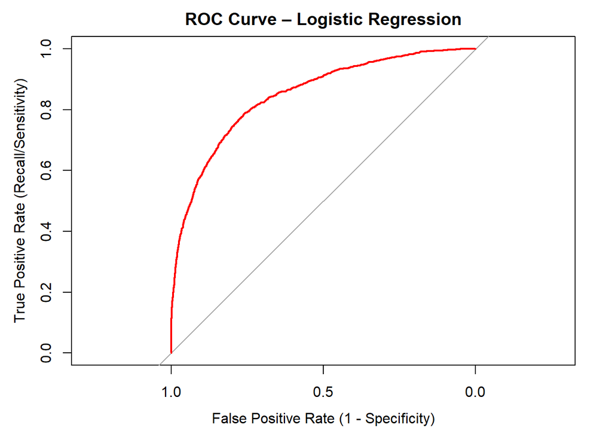

```r
roc_obj <- roc(test_data$loan_status, probabilities)

plot(roc_obj, col = "red", main = "ROC Curve – Logistic Regression",
     xlab = "False Positive Rate (1 - Specificity)",
     ylab = "True Positive Rate (Recall/Sensitivity)")
```

```r
auc_score <- auc(roc_obj)
cat("\nArea Under the ROC Curve (AUC):", round(auc_score, 4), "\n")
```

```
##
## Area Under the ROC Curve (AUC): 0.8478
```

```r
cat("Interpretation: An AUC of", round(auc_score, 4),
    "indicates the model has good discriminatory power.\n")
```

```
## Interpretation: An AUC of 0.8478 indicates the model has good discriminatory power.
```

```r
cat("AUC > 0.7 is considered acceptable, > 0.8 is good, > 0.9 is excellent.\n")
```

```
## AUC > 0.7 is considered acceptable, > 0.8 is good, > 0.9 is excellent.
```